# High Use Titles in Big 5 Providers

UVA StatLab/RDS

## High Use Journals

We began by evaluating the proportion of highly-used titles in 2017 within the Big 5 provider packages: the journals that account for the top X% of use, examined through multiple proxies for “use”, including

- all article downloads in 2017 (JR1)
- current year article downloads in 2017 (JR5)
- references to journal articles made by UVA authors from 2008-2017
- publications by UVA authors from 2008-2017

For each use metric we graph the percent of titles within each provider’s package that are among the top 80% used titles (JR80 Titles), the top 90% used titles (JR90 Titles), and the top 95% used titles (JR95 Titles) at UVA. The number of titles represented in each level of use is printed on the figures as well, along with the number of titles that make up the remaining 5% of use.

### 1a. High-use Journals by All Article Downloads

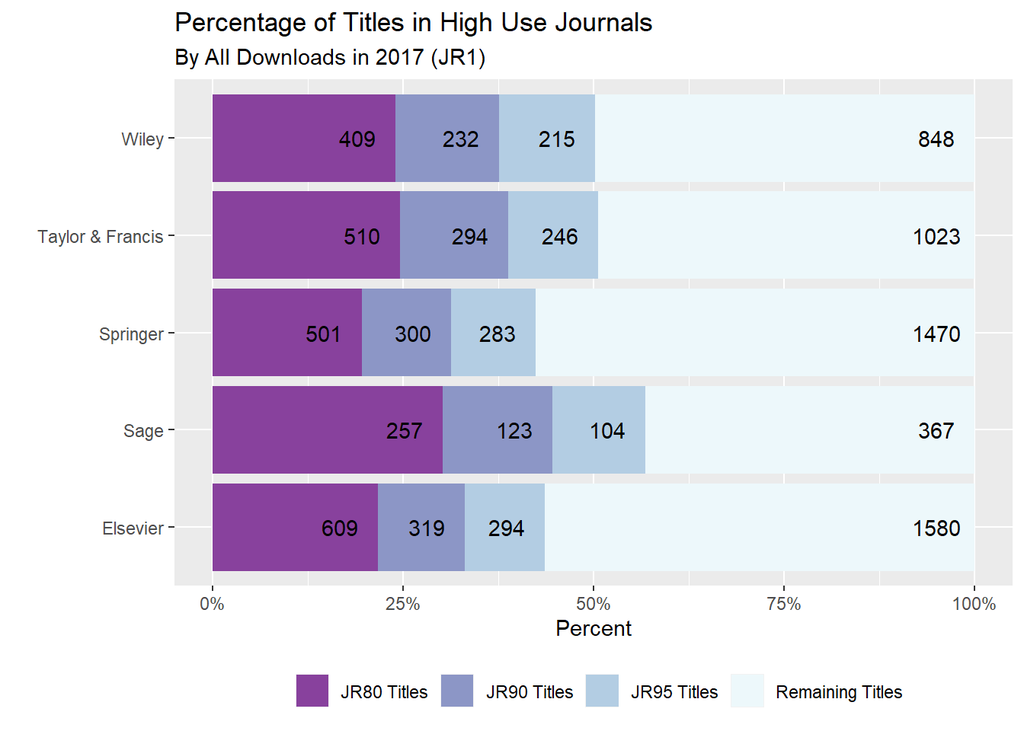

Among Elsevier journals, 609 or 21.7% of the titles are among the journals that make up 80% of downloads at UVA in 2017. Another 319 titles, or 33.1% overall, are among the journals that make up 90% of downloads at UVA. Including journals that make up 95% of downlaods adds another 294 titles from Elsevier, or 43.6% of the titles in the Elsevier package. Finally, 1580 journals in Elsevier’s package, or 56.4%, are not among the most highly-used journals at UVA by this metric.

The pattern for Springer is similar to that of Elsevier. Taylor & Francis and Wiley have a slightly higher ratio of high-use journals, while Sage has the highest rate of high-use journals.

### 1b. High-use Journals by Current Year Article Downloads

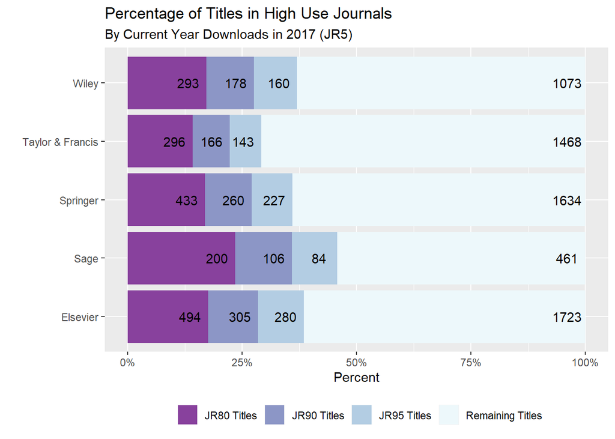

Looking at only downloads of articles from published in the current year, among Elsevier journals, 494 or 17.6% of the titles are among the journals that make up 80% of use at UVA. Another 305 titles, or 28.5% overall, are among the journals that make up 90% of current year downloads within Elsevier; and an additional 280 titles from Elsevier, or 38.5% of the titles in the Elsevier package, account for 95% of use. 1723 journals in Elsevier’s package, or 61.5%, are not among the most highly-used journals at UVA by this metric.

Both Springer and Wiley have similar ratios of high-use journals by current year downloads. Taylor & Francis has a lower ratio and Sage shows a higher ratio of highly-used journals by this metric.

### 1c. High-use Journals by References from UVA Authors

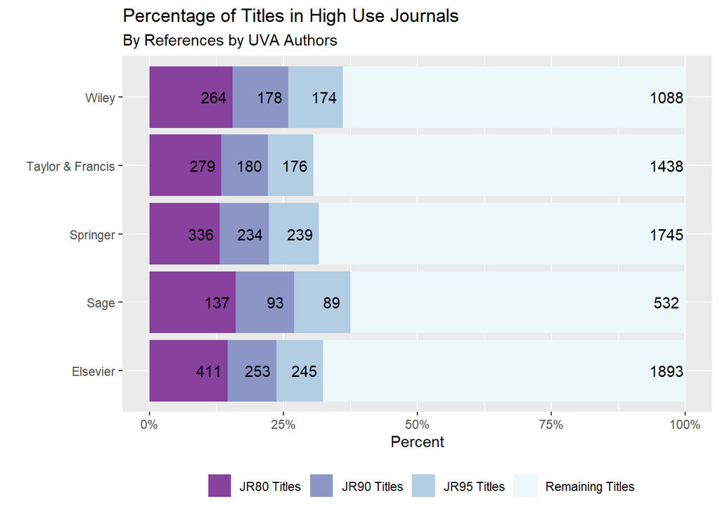

Measuring highly-used journals by focusing on the journals that UVA researchers have cited in the last 10 years shrinks the pool of titles categorized as high use. Among Elsevier journals, 411 or 14.7% of the titles are among the journals that make up 80% of references by researchers at UVA. Using the journals that make up 90% of references adds 253 Elsevier titles, or 23.7% of the package overall. Looking at the journals that make up 95% of references adds an additional 245 titles from Elsevier, or 32.4% of the titles in the Elsevier package. 1893 journals in Elsevier’s package, or 67.6%, are not among the most highly-used journals at UVA by this metric.

### 1d. High-use Journals by UVA-Authored Publications

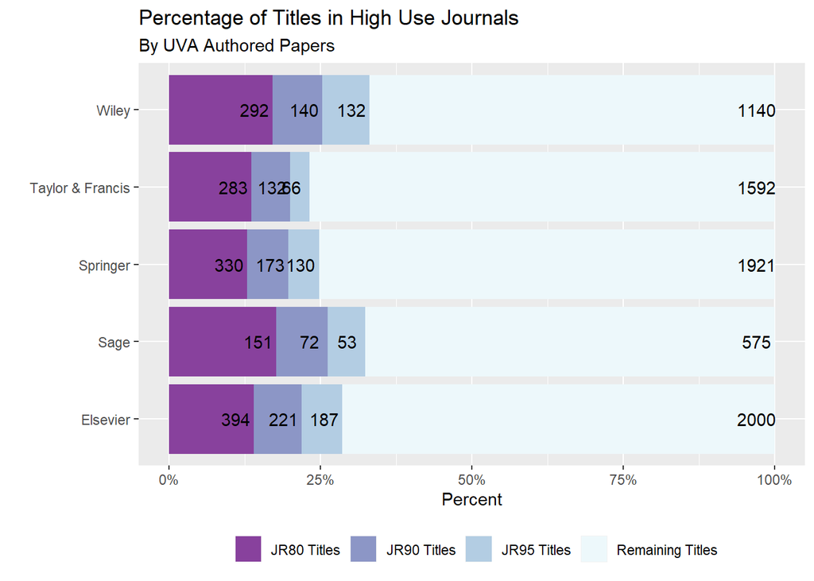

Focusing on the journals UVA researchers have published in over the last 10 years, 394 or 14.1% of Elsevier titles are among the journals that make up 80% of publications by UVA authors. The JR90 measure expands that to an additional 221 Elsevier titles, or 21.9% of the package; the JR95 measure expands that to 187 additional Elsevier titles, or 28.6% of the titles in the Elsevier package. 2000 journals in Elsevier’s package, or 71.4%, are not among the most highly-used journals at UVA by this metric.